# Establishing atttiudes towards novel stimuli via the IAT

# H4: Evaluative learning effect on the ratings is weakened when the analogy within the IAT is undermined

More specifically, the effect described in H2 should be lower in the non-opposite attributes IAT than the opposite attributes IAT. I.e., the difference between the conditions should itself be significant.

## Linear mixed model

```r
model_h4 <- lmer(ratings ~ IAT_condition * attribute_condition + (1 | participant),
                contrasts = list(IAT_condition = "contr.sum", attribute_condition = "contr.sum"),
                data = ratings_data)
```

## Summary

|  |  | B | CI | std. Beta | CI | p |
| --- | --- | --- | --- | --- | --- | --- |
| Fixed Parts |  |  |  |  |  |  |
| (Intercept) |  | 4.320 | 4.240 – 4.400 |  |  | .000000 |
| IAT_condition1 |  | -0.086 | -0.166 – -0.006 | -0.078 | -0.151 – -0.005 | .035479 |
| attribute_condition1 |  | -0.003 | -0.083 – 0.077 | -0.003 | -0.075 – 0.070 | .945818 |
| IAT_condition1:attribute_condition1 |  | 0.011 | -0.069 – 0.091 | 0.010 | -0.063 – 0.082 | .794896 |
| Random Parts |  |  |  |  |  |  |
| σ<sup>2</sup> |  | 0.597 |  |  |  |  |
| τ<sub>00, participant</sub> |  | 0.607 |  |  |  |  |
| N<sub>participant</sub> |  | 427 |  |  |  |  |
| ICC<sub>participant</sub> |  | 0.504 |  |  |  |  |
| Observations |  | 2562 |  |  |  |  |
| R<sup>2</sup> / Ω<sub>0</sub><sup>2</sup> |  | .587 / .575 |  |  |  |  |

## Plot effects

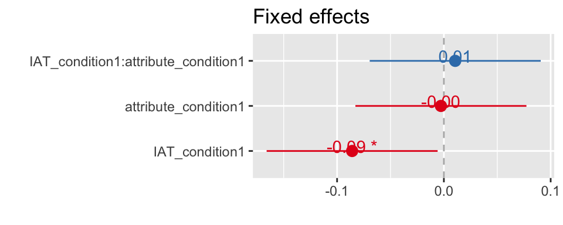

## Table predictions

| IAT condition | attribute_condition | fit | se | lower | upper |
| --- | --- | --- | --- | --- | --- |
| Flowers-Chinese IAT | nonword attributes | 4.24 | 0.08 | 4.08 | 4.40 |
| Insects-Chinese IAT | nonword attributes | 4.39 | 0.08 | 4.24 | 4.54 |
| Flowers-Chinese IAT | opposite valenced attributes | 4.23 | 0.08 | 4.07 | 4.38 |
| Insects-Chinese IAT | opposite valenced attributes | 4.42 | 0.09 | 4.25 | 4.59 |

## Plot predictions

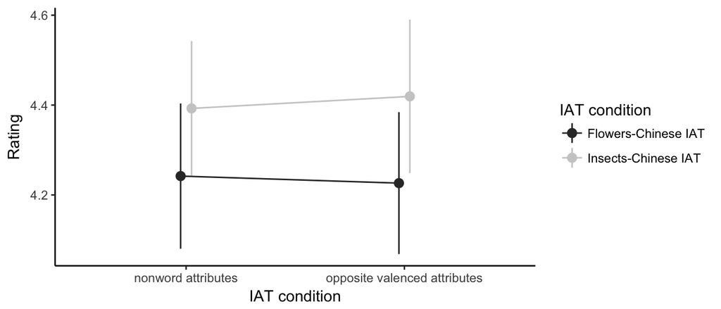

# E4: Impact of IAT block order on SCIAT effects between IAT contrast category conditions

Prompted by reviewer comments, we assessed whether the IAT block order influenced the effect in the condition where we expected to see it.

## Linear mixed model

- Hypothesis refers to the IAT_condition*iat_block_order*SCIAT_block interaction effect, which we expect to be non-significant.
- Confidence intervals via Wald estimation.

```r
# non-opposite condition only
SCIAT_data <- SCIAT_data %>%
  mutate(iat_block_order = as.factor(ifelse(as.numeric(as.character(participant)) %% 2 == 1, "compatible",
                                            ifelse(as.numeric(as.character(participant)) %% 2 == 0, "incompatible", NA))))

model_e4 <- lmer(recip_rt ~ SCIAT_block * IAT_condition * iat_block_order * attribute_condition + (SCIAT_block | participant),
                 contrasts = list(SCIAT_block = "contr.sum",
                                  IAT_condition = "contr.sum",
                                  iat_block_order = "contr.sum",
                                  attribute_condition = "contr.sum"),
                 data = SCIAT_data)
```

## Summary

|  |  | B | CI | std. Beta | CI | p |
| --- | --- | --- | --- | --- | --- | --- |
| Fixed Parts |  |  |  |  |  |  |
| (Intercept) |  | 1.688 | 1.669 – 1.708 |  |  | .000000 |
| SCIAT_block1 |  | 0.000 | -0.006 – 0.006 | 0.000 | -0.012 – 0.013 | .956641 |
| IAT_condition1 |  | 0.003 | -0.017 – 0.022 | 0.006 | -0.037 – 0.049 | .794792 |
| iat_block_order1 |  | 0.014 | -0.006 – 0.033 | 0.030 | -0.013 – 0.073 | .171653 |
| attribute_condition1 |  | -0.012 | -0.032 – 0.008 | -0.026 | -0.069 – 0.017 | .230267 |
| SCIAT_block1:IAT_condition1 |  | 0.011 | 0.005 – 0.016 | 0.023 | 0.010 – 0.036 | .000365 |
| SCIAT_block1:iat_block_order1 |  | 0.001 | -0.005 – 0.007 | 0.002 | -0.011 – 0.014 | .793869 |
| IAT_condition1:iat_block_order1 |  | -0.008 | -0.028 – 0.011 | -0.018 | -0.061 – 0.025 | .410672 |
| SCIAT_block1:attribute_condition1 |  | 0.004 | -0.002 – 0.010 | 0.009 | -0.004 – 0.022 | .158748 |
| IAT_condition1:attribute_condition1 |  | 0.005 | -0.015 – 0.025 | 0.011 | -0.032 – 0.053 | .623399 |
| iat_block_order1:attribute_condition1 |  | -0.005 | -0.024 – 0.015 | -0.010 | -0.053 – 0.032 | .631400 |
| SCIAT_block1:IAT_condition1:iat_block_order1 |  | -0.010 | -0.016 – -0.004 | -0.021 | -0.034 – -0.009 | .000895 |
| SCIAT_block1:IAT_condition1:attribute_condition1 |  | -0.006 | -0.011 – 0.000 | -0.012 | -0.025 – 0.001 | .061937 |
| SCIAT_block1:iat_block_order1:attribute_condition1 |  | -0.004 | -0.010 – 0.002 | -0.009 | -0.022 – 0.003 | .147140 |
| IAT_condition1:iat_block_order1:attribute_condition1 |  | 0.006 | -0.013 – 0.026 | 0.014 | -0.029 – 0.056 | .530898 |
| SCIAT_block1:IAT_condition1:iat_block_order1:attribute_condition1 |  | -0.002 | -0.007 – 0.004 | -0.003 | -0.016 – 0.009 | .607063 |
| Random Parts |  |  |  |  |  |  |
| σ<sup>2</sup> |  | 0.167 |  |  |  |  |
| τ<sub>00, participant</sub> |  | 0.045 |  |  |  |  |
| ρ<sub>01</sub> |  | -0.296 |  |  |  |  |
| N<sub>participant</sub> |  | 427 |  |  |  |  |
| ICC<sub>participant</sub> |  | 0.211 |  |  |  |  |
| Observations |  | 58739 |  |  |  |  |
| R<sup>2</sup> / Ω<sub>0</sub><sup>2</sup> |  | .214 / .213 |  |  |  |  |

## Plot effects

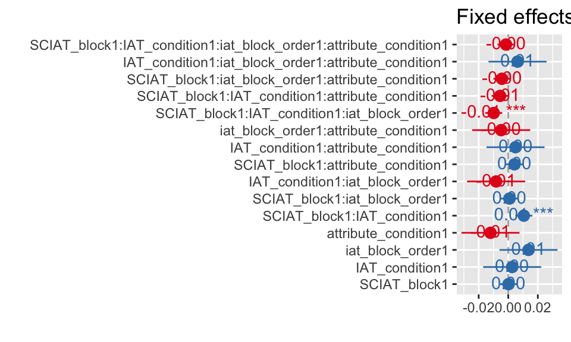

## Table predictions

| SCIAT block | IAT condition | iat_block_order | fit | se | lower | upper |
| --- | --- | --- | --- | --- | --- | --- |
| Chinese negative | Flowers-Chinese IAT | compatible | 1.70 | 0.02 | 1.66 | 1.74 |
| Chinese positive | Flowers-Chinese IAT | compatible | 1.69 | 0.02 | 1.66 | 1.73 |
| Chinese negative | Insects-Chinese IAT | compatible | 1.71 | 0.02 | 1.66 | 1.75 |
| Chinese positive | Insects-Chinese IAT | compatible | 1.71 | 0.02 | 1.66 | 1.75 |
| Chinese negative | Flowers-Chinese IAT | incompatible | 1.71 | 0.02 | 1.66 | 1.75 |
| Chinese positive | Flowers-Chinese IAT | incompatible | 1.67 | 0.02 | 1.62 | 1.71 |
| Chinese negative | Insects-Chinese IAT | incompatible | 1.64 | 0.02 | 1.60 | 1.68 |
| Chinese positive | Insects-Chinese IAT | incompatible | 1.68 | 0.02 | 1.64 | 1.72 |

## Plot predictions

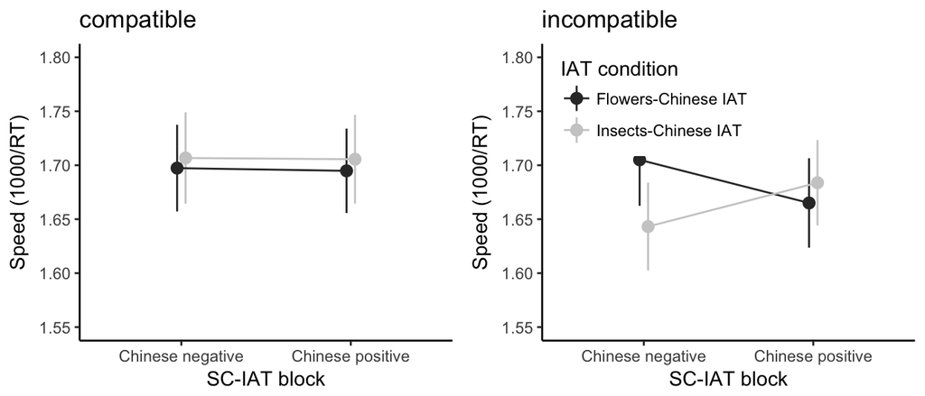

# E5: Impact of IAT block order on ratings effects between IAT contrast category conditions

Prompted by reviewer comments, we assessed whether the IAT block order influenced the effect in the condition where we expected to see it.

## Linear mixed model

- Hypothesis refers to the IAT_condition*iat_block_order interaction effect, which we expect to be non-significant.
- Confidence intervals via Wald estimation.

```r
# non-opposite condition only
ratings_data <- ratings_data %>%
  mutate(iat_block_order = as.factor(ifelse(as.numeric(as.character(participant)) %% 2 == 1, "compatible",
                                            ifelse(as.numeric(as.character(participant)) %% 2 == 0, "incompatible", NA))))

model_e5 <- lmer(ratings ~ IAT_condition * attribute_condition * iat_block_order + (1 | participant),
                contrasts = list(IAT_condition = "contr.sum",
                                 attribute_condition = "contr.sum",
                                 iat_block_order = "contr.sum"),
                data = ratings_data)
```

## Summary

|  |  | B | CI | std. Beta | CI | p |
| --- | --- | --- | --- | --- | --- | --- |
| Fixed Parts |  |  |  |  |  |  |
| (Intercept) |  | 4.315 | 4.234 – 4.395 |  |  | .000000 |
| IAT_condition1 |  | -0.080 | -0.160 – -0.000 | -0.073 | -0.146 – -0.000 | .049825 |
| attribute_condition1 |  | -0.012 | -0.092 – 0.068 | -0.011 | -0.084 – 0.062 | .773248 |
| iat_block_order1 |  | -0.059 | -0.139 – 0.021 | -0.054 | -0.127 – 0.019 | .147613 |
| IAT_condition1:attribute_condition1 |  | 0.021 | -0.060 – 0.101 | 0.019 | -0.054 – 0.091 | .615542 |
| IAT_condition1:iat_block_order1 |  | 0.087 | 0.007 – 0.167 | 0.079 | 0.006 – 0.152 | .032769 |
| attribute_condition1:iat_block_order1 |  | -0.043 | -0.123 – 0.037 | -0.039 | -0.112 – 0.034 | .290674 |
| IAT_condition1:attribute_condition1:iat_block_order1 |  | 0.003 | -0.077 – 0.083 | 0.003 | -0.070 – 0.075 | .942646 |
| Random Parts |  |  |  |  |  |  |
| σ<sup>2</sup> |  | 0.597 |  |  |  |  |
| τ<sub>00, participant</sub> |  | 0.600 |  |  |  |  |
| N<sub>participant</sub> |  | 427 |  |  |  |  |
| ICC<sub>participant</sub> |  | 0.501 |  |  |  |  |
| Observations |  | 2562 |  |  |  |  |
| R<sup>2</sup> / Ω<sub>0</sub><sup>2</sup> |  | .586 / .575 |  |  |  |  |

## Plot effects

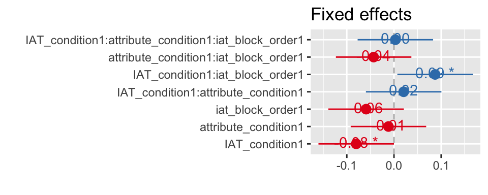

## Table predictions

| IAT condition | iat_block_order | fit | se | lower | upper |
| --- | --- | --- | --- | --- | --- |
| Flowers-Chinese IAT | compatible | 4.26 | 0.08 | 4.11 | 4.42 |
| Insects-Chinese IAT | compatible | 4.24 | 0.08 | 4.08 | 4.41 |
| Flowers-Chinese IAT | incompatible | 4.21 | 0.08 | 4.04 | 4.37 |
| Insects-Chinese IAT | incompatible | 4.54 | 0.08 | 4.38 | 4.70 |

## Plot predictions

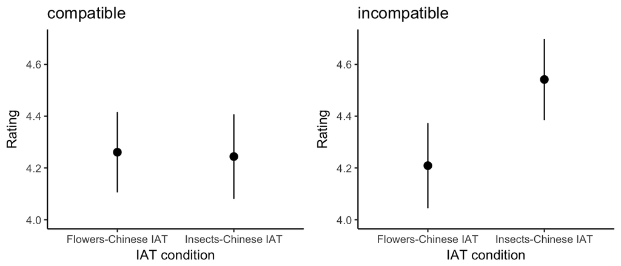

[^1]: Ghent University. Email: ian.hussey@ugent.be